# Sarath S_V01109792_SCMA632_Exam 2

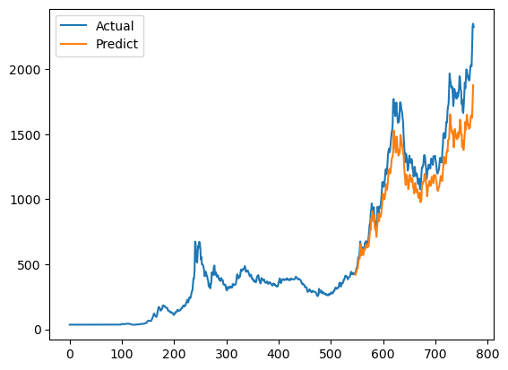

```python
##Plot baseline and predictions
f_data= scaler.inverse_transform(dataset)
train = trainPredictPlot
test = testPredictPlot

# plot baseline and predictions
plt.plot(f_data, label="Actual")
plt.plot(test, label="Predict")
plt.legend()
plt.show()
```

```python
actual_data = pd.DataFrame(f_data)
test_data = pd.DataFrame(testPredictPlot)
df = pd.DataFrame()
df['actual'] = actual_data
df['test'] = test_data
import os
os.getcwd()
df.to_csv("lstm10.csv")
```

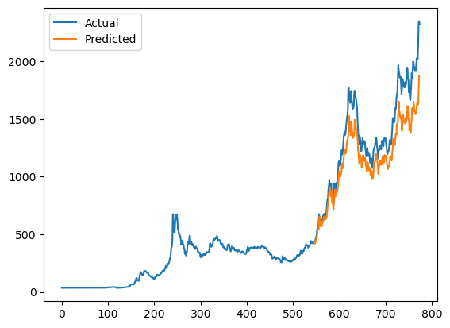

```python
plt.plot(f_data, label="Actual")
plt.plot(test, label="Predicted")
plt.legend()
plt.show()
```

#### The plot comparing actual gold prices (blue line) with the LSTM model’s predicted prices (orange line) demonstrates the model’s performance in forecasting gold prices over time. The actual data shows the historical fluctuations and trends in gold prices, including periods of stability and significant upward trends. The predicted prices generally follow the actual trend, capturing the overall direction and major movements. However, there are some discrepancies, particularly during periods of rapid price changes, where the model predictions either lag behind or fail to fully capture the volatility. This indicates that while the LSTM model is effective at modeling the long-term trend and general direction of gold prices, it may struggle with short-term precision and responsiveness to sudden market shifts. The visualization highlights the model’s strengths in trend prediction and areas for improvement in enhancing accuracy during volatile periods.